# R Notebook

## Homework week 10 - day 3

Manual model development

You are given a set of data on housing sale prices for the last few years in King County (near Seattle) between May 2014 and May 2015.

We want you to build an explanatory model for the price of housing in King County, i.e. an interpretable model in which the included variables are statistically justifiable.

```r
library(tidyverse)
library(fastDummies)
library(mosaicData)
library(tidyverse)
library(janitor)
library(GGally)
library(ggfortify)
library(mosaic)
library(skimr)
```

### Question 1

Load in data, explore and decide what to do with variables

```r
house_prices <- read_csv("data/kc_house_data.csv")
```

| id | date | price | bedrooms | bathrooms | sqft_living | sqft_lot | floors | waterfront | view | condition | grade | sqft_above | sqft_basement | yr_built | yr_renovated | zipcode | lat | long | sqft_living15 | sqft_lot15 |
| --- | --- | --- | --- | --- | --- | --- | --- | --- | --- | --- | --- | --- | --- | --- | --- | --- | --- | --- | --- | --- |
| 7129300520 | 2014-10-13 | 221900 | 3 | 1.00 | 1180 | 5650 | 1 | 0 | 0 | 3 | 7 | 1180 | 0 | 1955 | 0 | 98178 | 47.5112 | -122.257 | 1340 | 5650 |
| 6414100192 | 2014-12-09 | 538000 | 3 | 2.25 | 2570 | 7242 | 2 | 0 | 0 | 3 | 7 | 2170 | 400 | 1951 | 1991 | 98125 | 47.7210 | -122.319 | 1690 | 7639 |
| 5631500400 | 2015-02-25 | 180000 | 2 | 1.00 | 770 | 10000 | 1 | 0 | 0 | 3 | 6 | 770 | 0 | 1933 | 0 | 98028 | 47.7379 | -122.233 | 2720 | 8062 |
| 2487200875 | 2014-12-09 | 604000 | 4 | 3.00 | 1960 | 5000 | 1 | 0 | 0 | 5 | 7 | 1050 | 910 | 1965 | 0 | 98136 | 47.5208 | -122.393 | 1360 | 5000 |
| 1954400510 | 2015-02-18 | 510000 | 3 | 2.00 | 1680 | 8080 | 1 | 0 | 0 | 3 | 8 | 1680 | 0 | 1987 | 0 | 98074 | 47.6168 | -122.045 | 1800 | 7503 |
| 7237550310 | 2014-05-12 | 1225000 | 4 | 4.50 | 5420 | 101930 | 1 | 0 | 0 | 3 | 11 | 3890 | 1530 | 2001 | 0 | 98053 | 47.6561 | -122.005 | 4760 | 101930 |

```r
# columns date, id, sqft_living15, sqft_lot15 and zipcode non informative
house_tidy <- house_prices %>%
  select(-id, -date, -sqft_living15, -sqft_lot15, -zipcode) %>%
  #waterfront is a logical, TRUE/FALSE so lets convert:
  mutate(waterfront = if_else(waterfront > 0, TRUE, FALSE)) %>%
#lets convert yr_renovated into a logical also, to see if renovation has a effect
 mutate(renovated = if_else(yr_renovated > 0, TRUE, FALSE)) %>%
  select(-yr_renovated) %>%
  # Variables, 'view', 'condition' and 'grade' can be seen as ordinal data.
  # they are representing non-mathematical ideas (eventhough written here as number)
  mutate(view = as_factor(view),
         condition = as_factor(condition),
         grade = as_factor(grade))
```

| price | bedrooms | bathrooms | sqft_living | sqft_lot | floors | waterfront | view | condition | grade | sqft_above | sqft_basement | yr_built | lat | long | renovated |
| --- | --- | --- | --- | --- | --- | --- | --- | --- | --- | --- | --- | --- | --- | --- | --- |
| 221900 | 3 | 1.00 | 1180 | 5650 | 1.0 | FALSE | 0 | 3 | 7 | 1180 | 0 | 1955 | 47.5112 | -122.257 | FALSE |
| 538000 | 3 | 2.25 | 2570 | 7242 | 2.0 | FALSE | 0 | 3 | 7 | 2170 | 400 | 1951 | 47.7210 | -122.319 | TRUE |
| 180000 | 2 | 1.00 | 770 | 10000 | 1.0 | FALSE | 0 | 3 | 6 | 770 | 0 | 1933 | 47.7379 | -122.233 | FALSE |
| 604000 | 4 | 3.00 | 1960 | 5000 | 1.0 | FALSE | 0 | 5 | 7 | 1050 | 910 | 1965 | 47.5208 | -122.393 | FALSE |
| 510000 | 3 | 2.00 | 1680 | 8080 | 1.0 | FALSE | 0 | 3 | 8 | 1680 | 0 | 1987 | 47.6168 | -122.045 | FALSE |
| 1225000 | 4 | 4.50 | 5420 | 101930 | 1.0 | FALSE | 0 | 3 | 11 | 3890 | 1530 | 2001 | 47.6561 | -122.005 | FALSE |
| 257500 | 3 | 2.25 | 1715 | 6819 | 2.0 | FALSE | 0 | 3 | 7 | 1715 | 0 | 1995 | 47.3097 | -122.327 | FALSE |
| 291850 | 3 | 1.50 | 1060 | 9711 | 1.0 | FALSE | 0 | 3 | 7 | 1060 | 0 | 1963 | 47.4095 | -122.315 | FALSE |
| 229500 | 3 | 1.00 | 1780 | 7470 | 1.0 | FALSE | 0 | 3 | 7 | 1050 | 730 | 1960 | 47.5123 | -122.337 | FALSE |
| 323000 | 3 | 2.50 | 1890 | 6560 | 2.0 | FALSE | 0 | 3 | 7 | 1890 | 0 | 2003 | 47.3684 | -122.031 | FALSE |

[output cut: 990 more lines]

### Question 2

Check for aliased variables using the alias() function (this takes in a formula object and a data set).

```r
alias(lm(price ~ ., data = house_tidy))
```

```
Model :
price ~ bedrooms + bathrooms + sqft_living + sqft_lot + floors +
    waterfront + view + condition + grade + sqft_above + sqft_basement +
    yr_built + lat + long + renovated

Complete :
              (Intercept) bedrooms bathrooms sqft_living sqft_lot floors waterfrontTRUE view1 view2 view3 view4 condition2
sqft_basement  0           0        0         1           0        0      0              0     0     0     0     0
              condition3 condition4 condition5 grade3 grade4 grade5 grade6 grade7 grade8 grade9 grade10 grade11 grade12
sqft_basement  0          0          0          0      0      0      0      0      0      0      0       0       0
              grade13 sqft_above yr_built lat long renovatedTRUE
sqft_basement  0      -1          0        0   0    0
```

So based on this output we see that sqft_basement can be calculated as: sqft_basement = 1 * sqft_living + -1 * sqft_above

So I suggest to remove sqft_basement

```r
house_tidy_2 <- house_tidy %>%
  select(-sqft_basement)
```

```r
alias(lm(price ~ ., data = house_tidy_2))
```

```
Model :
price ~ bedrooms + bathrooms + sqft_living + sqft_lot + floors +
    waterfront + view + condition + grade + sqft_above + yr_built +
    lat + long + renovated
```

Success!!!

### Question 3

Systematically build a regression model containing up to four main effects (remember, a main effect is just a single predictor with coefficient), testing the regression diagnostics as you go * splitting datasets into numeric and non-numeric columns might help ggpairs() run in manageable time, although you will need to add either a price or resid column to the non-numeric dataframe in order to see its correlations with the non-numeric predictors.

```r
# start checking correlations for numeric only first, than non-numeric..
# to keep things manageable!

# Numeric
house_tidy_numeric <- house_tidy_2 %>%
  select_if(is.numeric)

# non-numeric
house_tidy_nonnum <- house_tidy_2 %>%
  select_if(~!is.numeric(.))

# add price column to the non-numeric data
house_tidy_nonnum$price <- house_tidy_2$price
```

**First predictor** First ggpairs of numeric variables:

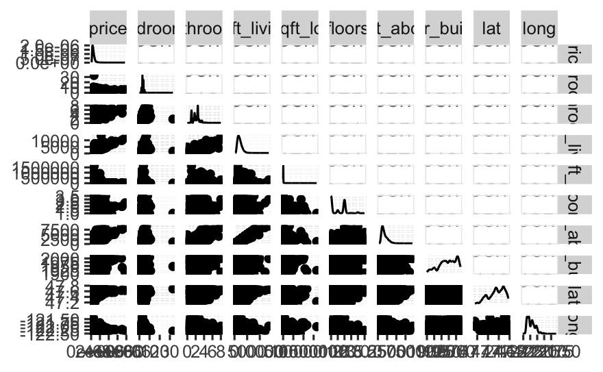

Based on the plot, highest correlation with price = sqft_living Let’s create a model:

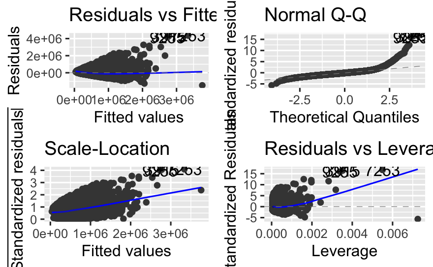

```r
model_1 <- lm(price ~ sqft_living, house_tidy_2)

autoplot(model_1)
```

```r
summary(model_1)
```

```
Call:
lm(formula = price ~ sqft_living, data = house_tidy_2)

Residuals:
     Min       1Q   Median       3Q      Max
-1476062  -147486   -24043   106182  4362067

Coefficients:
              Estimate Std. Error t value Pr(>|t|)
(Intercept) -43580.743   4402.690  -9.899   <2e-16 ***
sqft_living    280.624      1.936 144.920   <2e-16 ***
---
Signif. codes:  0 ‘***’ 0.001 ‘**’ 0.01 ‘*’ 0.05 ‘.’ 0.1 ‘ ’ 1

Residual standard error: 261500 on 21611 degrees of freedom
Multiple R-squared:  0.4929,    Adjusted R-squared:  0.4928
F-statistic: 2.1e+04 on 1 and 21611 DF,  p-value: < 2.2e-16
```

```r
# Residual standard error: 261500
# Multiple R-squared:  0.4929
# significant relation
```

**Second predictor**

**Question: why do we add the residuals and check correlations using that?**

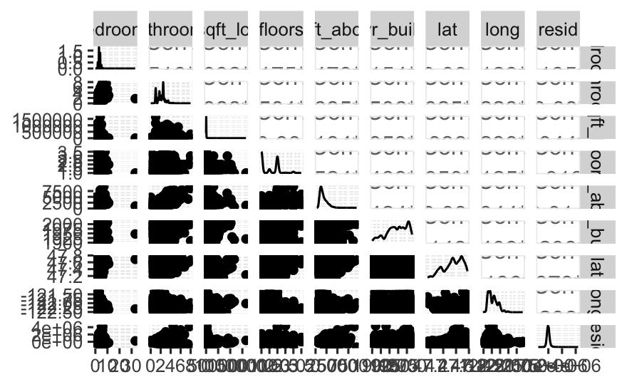

```r
library(modelr)
house_tidy_numeric_remaining_resid <- house_tidy_numeric %>%
  add_residuals(model_1) %>%
  select(-c("price", "sqft_living"))


ggpairs(house_tidy_numeric_remaining_resid)
```

Based on the plot, highest correlation now with residuals = latitude Let’s add it as predictor to our model:

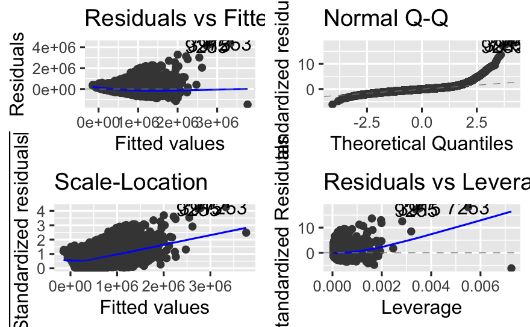

```r
autoplot(model_2)
summary(model_2)
```

```
Call:
lm(formula = price ~ sqft_living + lat, data = house_tidy_2)

Residuals:
     Min       1Q   Median       3Q      Max
-1487994  -125643   -20309    84613  4368717

Coefficients:
              Estimate Std. Error t value Pr(>|t|)
(Intercept) -3.416e+07  5.653e+05  -60.44   <2e-16 ***
sqft_living  2.749e+02  1.794e+00  153.27   <2e-16 ***
lat          7.177e+05  1.189e+04   60.36   <2e-16 ***
---
Signif. codes:  0 ‘***’ 0.001 ‘**’ 0.01 ‘*’ 0.05 ‘.’ 0.1 ‘ ’ 1

Residual standard error: 241900 on 21610 degrees of freedom
Multiple R-squared:  0.566, Adjusted R-squared:  0.566
F-statistic: 1.409e+04 on 2 and 21610 DF,  p-value: < 2.2e-16
```

Improved in comparison to model_1, so let’s continue and add another predictor

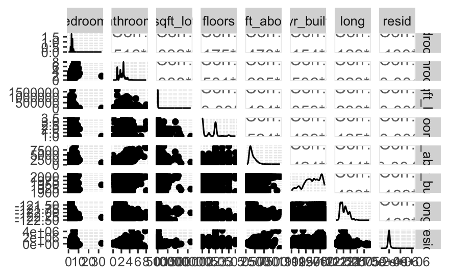

Based on the plot, all correlations are pretty weak, so I want to check the non-numerical dataset now…!

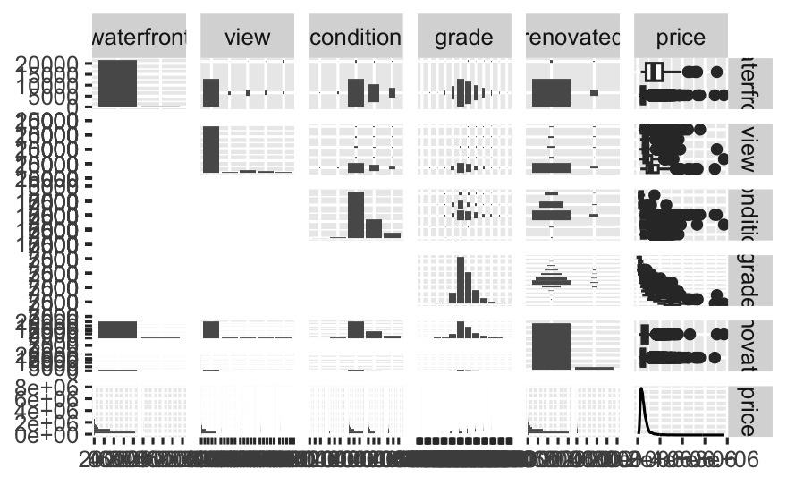

Based on this plot, it looks like “grade” has an effect on the price. The boxplots of grade show splitting. So lets add grade to our model as predictor

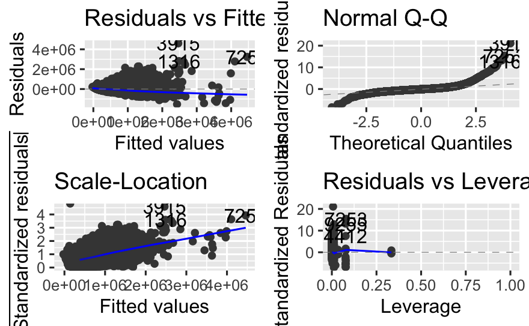

```r
autoplot(model_3)
summary(model_3)
```

```
Call:
lm(formula = price ~ sqft_living + lat + grade, data = house_tidy_2)

Residuals:
     Min       1Q   Median       3Q      Max
-1528796  -105592   -19877    65573  4599064

Coefficients:
              Estimate Std. Error t value Pr(>|t|)
(Intercept) -3.167e+07  5.600e+05 -56.560  < 2e-16 ***
sqft_living  1.653e+02  2.568e+00  64.377  < 2e-16 ***
lat          6.684e+05  1.084e+04  61.643  < 2e-16 ***
grade3       1.442e+05  2.529e+05   0.570  0.56873
grade4       3.540e+04  2.228e+05   0.159  0.87373
grade5       1.285e+04  2.195e+05   0.059  0.95332
grade6       9.338e+03  2.191e+05   0.043  0.96601
grade7       1.415e+04  2.191e+05   0.065  0.94851
grade8       6.418e+04  2.191e+05   0.293  0.76958
grade9       1.752e+05  2.192e+05   0.800  0.42399
grade10      3.556e+05  2.193e+05   1.622  0.10486
grade11      6.300e+05  2.196e+05   2.869  0.00412 **
grade12      1.148e+06  2.207e+05   5.204 1.97e-07 ***
grade13      2.309e+06  2.281e+05  10.126  < 2e-16 ***
---
Signif. codes:  0 ‘***’ 0.001 ‘**’ 0.01 ‘*’ 0.05 ‘.’ 0.1 ‘ ’ 1

Residual standard error: 219000 on 21599 degrees of freedom
Multiple R-squared:  0.6443,    Adjusted R-squared:  0.644
F-statistic:  3009 on 13 and 21599 DF,  p-value: < 2.2e-16
```

Let’s also check if adding the categorical predictor ‘grade’ is also statistically justified:

```r
anova(model_2, model_3)
```

```
Analysis of Variance Table

Model 1: price ~ sqft_living + lat
Model 2: price ~ sqft_living + lat + grade
  Res.Df        RSS Df  Sum of Sq      F    Pr(>F)
1  21610 1.2641e+15
2  21599 1.0363e+15 11 2.2788e+14 431.79 < 2.2e-16 ***
---
Signif. codes:  0 ‘***’ 0.001 ‘**’ 0.01 ‘*’ 0.05 ‘.’ 0.1 ‘ ’ 1
```

Improved in comparison to model_2, and adding “grade” is statistically justified! so let’s continue and add another predictor

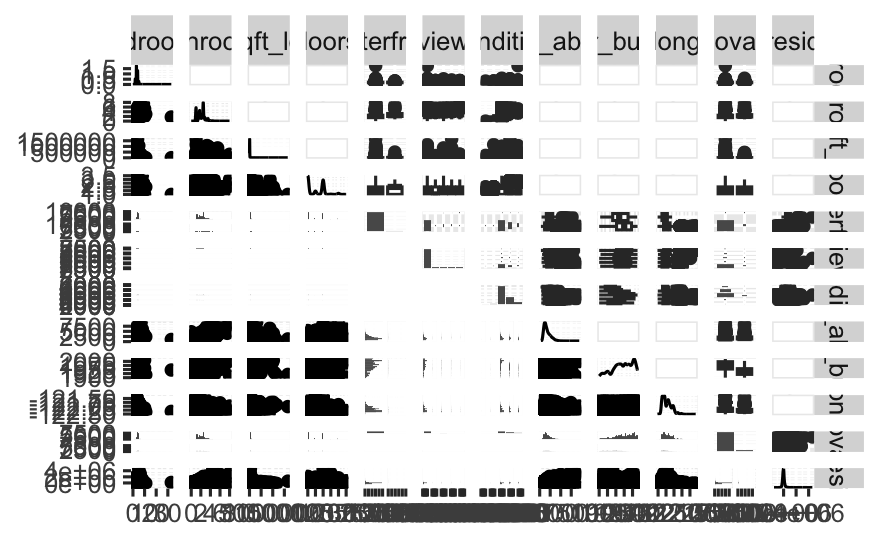

**question: how to deal with the size of this plot?**

```r
colnames(house_tidy_remaining_resid)
```

```
 [1] "bedrooms"   "bathrooms"  "sqft_lot"   "floors"     "waterfront" "view"       "condition"  "sqft_above" "yr_built"
[10] "long"       "renovated"  "resid"
```

Difficult to see, but it looks like predictor “year_built” has still a negative correlation with the price. Let’s add to our model

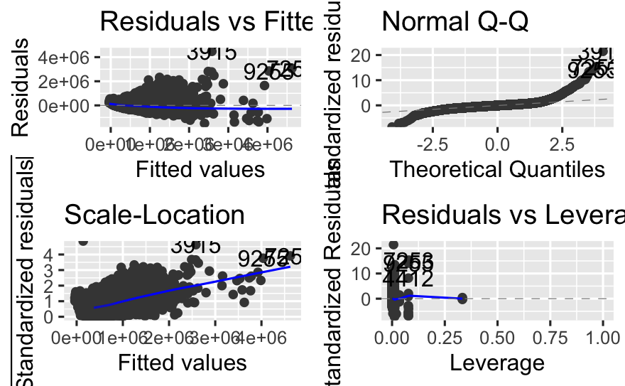

```r
autoplot(model_4)
summary(model_4)
```

```
Call:
lm(formula = price ~ sqft_living + lat + grade + yr_built, data = house_tidy_2)

Residuals:
     Min       1Q   Median       3Q      Max
-1493935   -99411   -13537    72530  4481513

Coefficients:
              Estimate Std. Error t value Pr(>|t|)
(Intercept) -2.132e+07  5.829e+05 -36.568  < 2e-16 ***
sqft_living  1.634e+02  2.456e+00  66.534  < 2e-16 ***
lat          5.566e+05  1.066e+04  52.198  < 2e-16 ***
grade3       7.742e+04  2.419e+05   0.320 0.748918
grade4      -2.924e+04  2.130e+05  -0.137 0.890852
grade5      -6.008e+04  2.099e+05  -0.286 0.774709
grade6      -4.141e+04  2.095e+05  -0.198 0.843332
grade7       2.096e+04  2.095e+05   0.100 0.920318
grade8       1.164e+05  2.095e+05   0.556 0.578484
grade9       2.505e+05  2.096e+05   1.195 0.232081
grade10      4.368e+05  2.097e+05   2.083 0.037287 *
grade11      7.204e+05  2.100e+05   3.431 0.000602 ***
grade12      1.241e+06  2.110e+05   5.881 4.14e-09 ***
grade13      2.370e+06  2.181e+05  10.865  < 2e-16 ***
yr_built    -2.568e+03  5.712e+01 -44.968  < 2e-16 ***
---
Signif. codes:  0 ‘***’ 0.001 ‘**’ 0.01 ‘*’ 0.05 ‘.’ 0.1 ‘ ’ 1

Residual standard error: 209500 on 21598 degrees of freedom
Multiple R-squared:  0.6747,    Adjusted R-squared:  0.6745
F-statistic:  3200 on 14 and 21598 DF,  p-value: < 2.2e-16
```

Adding year built improved the model, and is significnat.

The final regression model containing four main effects =

price ~ sqft_living + lat + grade + yr_built

## Extension

1. Consider possible interactions between your four main effect predictors and test their effect upon r2 . Choose your best candidate interaction and visualise its effect.

```r
autoplot(model_5)
summary(model_5)
```

```
Call:
lm(formula = price ~ sqft_living + lat + grade + yr_built + yr_built:grade,
    data = house_tidy_2)

Residuals:
     Min       1Q   Median       3Q      Max
-1642632   -94343   -11736    67718  4170984

Coefficients: (1 not defined because of singularities)
                   Estimate Std. Error t value Pr(>|t|)
(Intercept)      -8.469e+06  3.511e+06  -2.412  0.01587 *
sqft_living       1.614e+02  2.414e+00  66.866  < 2e-16 ***
lat               5.764e+05  1.048e+04  55.023  < 2e-16 ***
grade3           -8.230e+06  1.256e+07  -0.655  0.51228
grade4           -2.206e+07  5.135e+06  -4.296 1.75e-05 ***
grade5           -1.829e+07  3.725e+06  -4.910 9.19e-07 ***
grade6           -1.760e+07  3.500e+06  -5.028 5.01e-07 ***
grade7           -1.559e+07  3.478e+06  -4.481 7.47e-06 ***
grade8           -1.378e+07  3.479e+06  -3.960 7.53e-05 ***
grade9           -8.745e+06  3.489e+06  -2.507  0.01220 *
grade10          -2.991e+06  3.516e+06  -0.851  0.39490
grade11          -8.168e+05  3.623e+06  -0.225  0.82162
grade12          -1.948e+07  4.041e+06  -4.821 1.44e-06 ***
grade13           2.477e+06  2.147e+05  11.536  < 2e-16 ***
yr_built         -9.595e+03  1.767e+03  -5.430 5.69e-08 ***
grade3:yr_built   4.209e+03  6.451e+03   0.653  0.51408
grade4:yr_built   1.127e+04  2.631e+03   4.285 1.84e-05 ***
grade5:yr_built   9.319e+03  1.898e+03   4.909 9.21e-07 ***
grade6:yr_built   8.964e+03  1.780e+03   5.035 4.81e-07 ***
grade7:yr_built   7.951e+03  1.769e+03   4.495 6.99e-06 ***
grade8:yr_built   7.078e+03  1.769e+03   4.001 6.34e-05 ***
grade9:yr_built   4.616e+03  1.774e+03   2.602  0.00928 **
grade10:yr_built  1.820e+03  1.788e+03   1.018  0.30879
grade11:yr_built  8.778e+02  1.841e+03   0.477  0.63342
grade12:yr_built  1.051e+04  2.048e+03   5.131 2.91e-07 ***
grade13:yr_built         NA         NA      NA       NA
---
Signif. codes:  0 ‘***’ 0.001 ‘**’ 0.01 ‘*’ 0.05 ‘.’ 0.1 ‘ ’ 1

Residual standard error: 204900 on 21588 degrees of freedom
Multiple R-squared:  0.6889,    Adjusted R-squared:  0.6886
F-statistic:  1992 on 24 and 21588 DF,  p-value: < 2.2e-16
```

2. Calculate the relative importance of predictors from your best 4 -predictor model (i.e. the model without an interaction). Which predictor affects price most strongly?

```r
calc.relimp(model_4, type = "lmg", rela = TRUE)
```

```
Response variable: price
Total response variance: 134782378397
Analysis based on 21613 observations

14 Regressors:
Some regressors combined in groups:
        Group  grade : grade3 grade4 grade5 grade6 grade7 grade8 grade9 grade10 grade11 grade12 grade13

 Relative importance of 4 (groups of) regressors assessed:
 grade sqft_living lat yr_built

Proportion of variance explained by model: 67.47%
Metrics are normalized to sum to 100% (rela=TRUE).

Relative importance metrics:

                   lmg
grade       0.45234793
sqft_living 0.41292696
lat         0.09809759
yr_built    0.03662753

Average coefficients for different model sizes:

                  1group      2groups      3groups      4groups
sqft_living     280.6236     245.6026     205.1658     163.3972
lat          813411.5832  734705.1674  614095.2077  556557.5636
grade3        63666.6672   69680.5509   73701.3572   77416.5146
grade4        72381.0351   34514.9701      86.4573  -29235.6859
grade5       106523.9716   46648.4183   -9624.3207  -60079.1942
grade6       159919.6380   89701.2340   21910.3579  -41409.2380
grade7       260590.2629  183125.4894  102723.8679   20956.8440
grade8       400852.7662  313128.1313  217874.3072  116416.1783
grade9       631513.1864  514630.5870  387044.8629  250482.0434
grade10      929771.0746  776778.8055  611642.6363  436768.8912
grade11     1354841.7274 1156878.2824  944314.7067  720448.1332
grade12     2049222.0006 1795614.3859 1524679.6350 1240983.8377
grade13     3567615.3852 3183496.6514 2781641.5453 2369661.2778
yr_built        675.0698   -1454.6530   -2561.6237   -2568.4167
```

So, we see by this measure that *grade* is most important (accounting for 45% of r2 ), followed by *sqft_living* (41% ), then *latitude* (9% ), and finally the *yr_built* (4% ).